# Reinvestigating Cancer Microbes

Author

Abraham Gihawi

## Introduction

This study reanalyses data from [Poore et al 2020](https://doi.org/10.1038/s41586-020-2095-1). The authors have made their data available at this [FTP](https://ftp.microbio.me/pub/cancer_microbiome_analysis/TCGA/Kraken/). Let’s load in the packages we will need and read the data straight from the FTP.

### Loading in the packages and data

```r
set.seed(4)
Sys.setenv("VROOM_CONNECTION_SIZE" = 300000)


r = getOption("repos")
r["CRAN"] = "https://cran.ma.imperial.ac.uk"
options(repos = r)

packages <- c("readr", "dplyr", "tidyr", "tibble", "ggsurvfit", "survival", "Boruta", "DataExplorer","broom","knitr", "ggfortify", "BiocManager","curl")

# Install packages not yet installed
installed_packages <- packages %in% rownames(installed.packages())
if (any(installed_packages == FALSE)) {
  install.packages(packages[!installed_packages], dependicies = TRUE)
}

# Packages loading
invisible(lapply(packages, library, character.only = TRUE))

#now for bioconductor
BiocManager::install("limma")

library(limma)



raw_data <- read_csv('https://github.com/UEA-Cancer-Genetics-Lab/MMB-masterclass-biomarkers/raw/refs/heads/main/Data/Kraken-TCGA-Raw-Data-17625-Samples.csv')
stringent_decontamination <- read_csv('https://github.com/UEA-Cancer-Genetics-Lab/MMB-masterclass-biomarkers/raw/refs/heads/main/Data/Kraken-TCGA-Voom-SNM-Most-Stringent-Filtering-Data.csv')
metadata <- read_csv('https://github.com/UEA-Cancer-Genetics-Lab/MMB-masterclass-biomarkers/raw/refs/heads/main/Data/Metadata-TCGA-All-18116-Samples.csv')
```

### Plot a PCA to look at the structure of the data

Look at the raw data in a PCA plot to get a general idea of the structure. Plot the data and colour it by data submitting center and by disease type.

Try to do it on your own. But you can view the code if you need a hand!

- Hint - You will need to use the `voom` function to normalise the raw data before visualising.

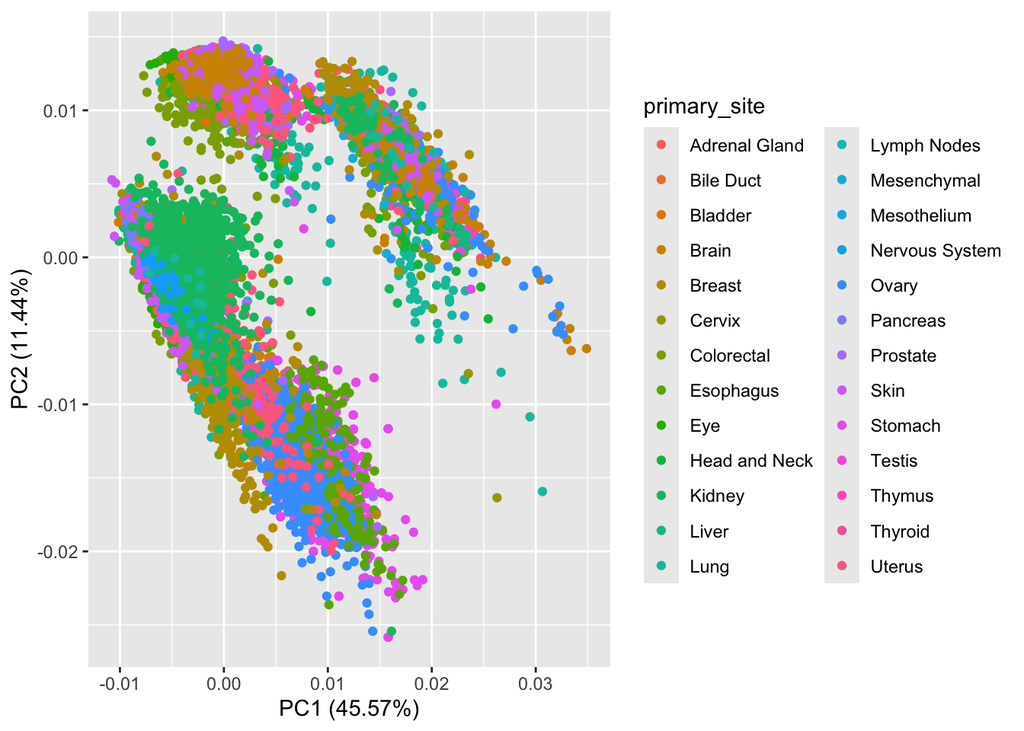

```r
# rename column. names to something workable and not "...1"
colnames(raw_data)[1] <- 'sampleid'
colnames(metadata)[1] <- 'sampleid'
colnames(stringent_decontamination)[1] <- 'sampleid'

raw_metadata <- merge(raw_data, metadata, by="sampleid", all=FALSE)

#reselect
matched_raw <- raw_metadata %>% select(-colnames(metadata))
matched_raw_norm <- voom(matched_raw)


pca_res <- prcomp(matched_raw_norm, scale. = FALSE)

autoplot(pca_res, data = raw_metadata, colour = 'primary_site', label = FALSE)
```

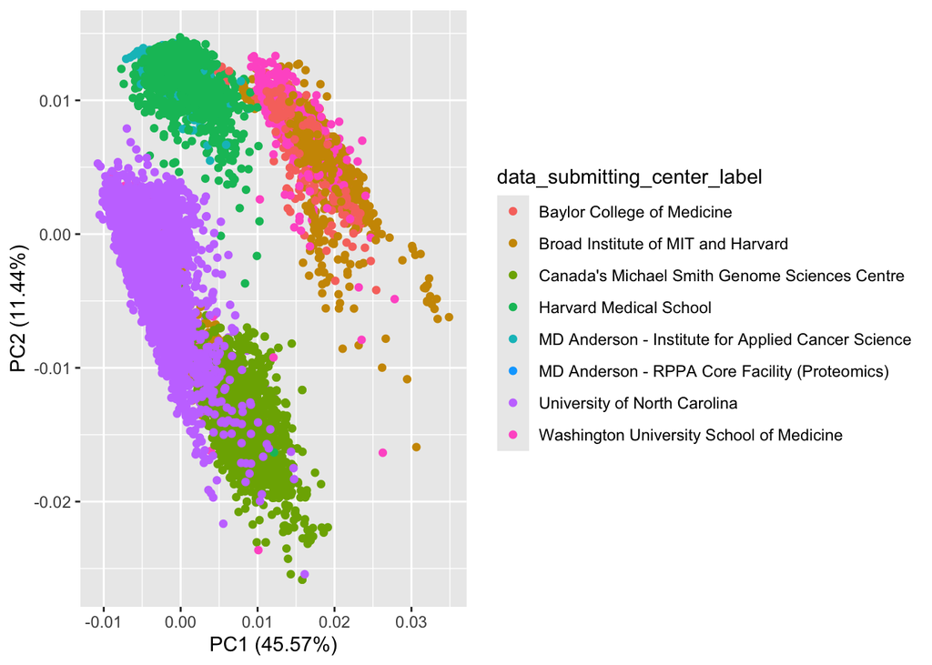

```r
autoplot(pca_res, data = raw_metadata, colour = 'data_submitting_center_label', label = FALSE)
```

Is there any structure by disease type? A little bit. But Nothing major, the whole thing is confounded by an even more prominent batch effect by where the data came from. The authors claimed to have fixed this by turning everything into one central ‘blob’ after a supervised normalisation process ([Figure 1d](https://www.nature.com/articles/s41586-020-2095-1/figures/1)).

### Plot individual taxa to look at the raw/normalised values

So what is going on with these normalised values? Let’s look at a really sparse feature, a genus called Hepandensovirus. This was the top weighted feature to predict adrenocortical carcinoma vs all other features in their most stringent decontamination approach.

- isolate the raw values for hepandensovirus and sampleid
- isolate the normalised values for hepandensorivus and sampleid
- merge these with the metadata
- plot the values for this feature before and after normalisation in histograms

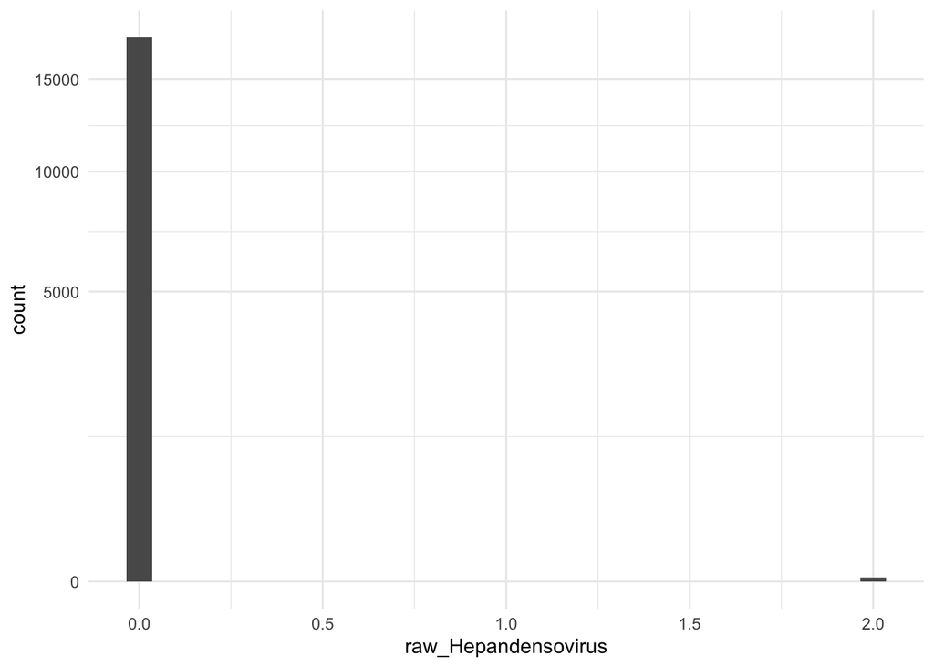

```r
#find raw read counts
hep_raw <- raw_data %>% select(sampleid, k__Viruses.f__Parvoviridae.g__Hepandensovirus)
colnames(hep_raw) <- c('sampleid', 'raw_Hepandensovirus')

#find normalised read counts
hep_norm <- stringent_decontamination %>% select(sampleid, k__Viruses.f__Parvoviridae.g__Hepandensovirus)
colnames(hep_norm) <- c('sampleid', 'norm_Hepandensovirus')


#merge normalised read counts
hep <- merge(hep_raw, hep_norm, by='sampleid', all=FALSE)

hep <- merge(hep, metadata, by='sampleid', all=FALSE)

#plot raw_read counts
ggplot(hep, aes(x=raw_Hepandensovirus)) +
  geom_histogram() +
  theme_minimal() +
  scale_y_sqrt()
```

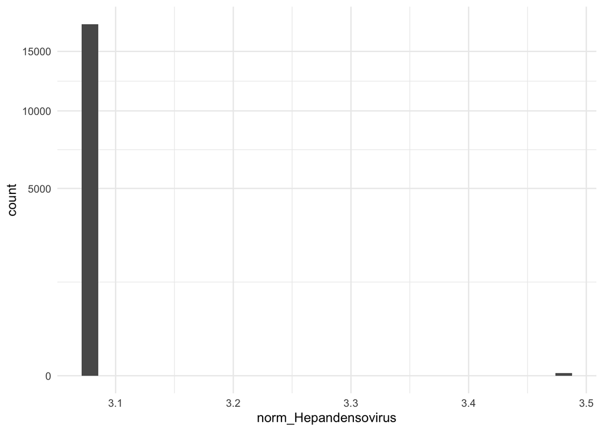

```r
#One sample is positive and has 2 sequencing reads assigned to it. How do the normalised values look?

#plot normalised
ggplot(hep, aes(x=norm_Hepandensovirus)) +
  geom_histogram() +
  theme_minimal() +
  scale_y_sqrt()
```

It looks perfectly normal. So why on earth is Hepandensovirus the top feature for predciting adrenocortical carcinoma? Only one sample is ‘positive’?

Take a look more closely into the ‘negative’ samples in the normalised data.

- Create a dataframe only containing values that were negative in the raw sequencing reads (before normalisation)
- Create a jitter plot (geom_jitter) of the normalised hepandensovirus vs the raw hepandensovirus in this dataset. Colour the points by data_submitting_center_label

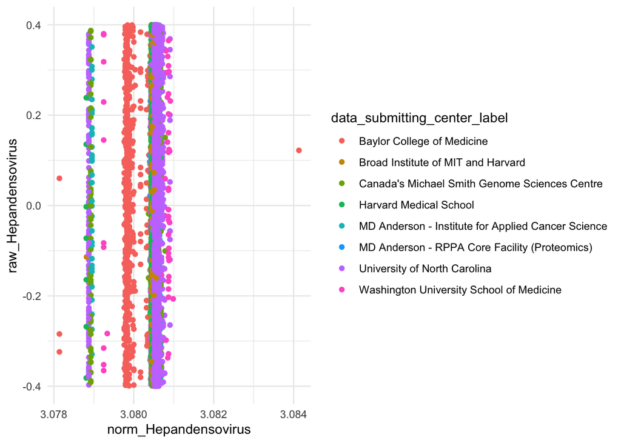

```r
hep_neg <- hep %>% filter(raw_Hepandensovirus ==0)

#plot normalised
ggplot(hep_neg, aes(x=norm_Hepandensovirus, y=raw_Hepandensovirus, col=data_submitting_center_label)) +
  geom_jitter() +
  theme_minimal()
```

Interesting. There still seems to be pretty clear differences between sequencing center, despite all values initially being zero. How would this affect disease classification? Let’s re-plot the data, colouring by disease type.

- Convert the normalised hepandensovirus to a character (this is unorthodox, but will be easier to display exact values)
- Make a new variable, highlighting which cases are adrenocortical carcinoma (ACC) vs all others
- Plot a bar plot of the counts for each of the normalised Hepandensovirus variables and colour by disease type

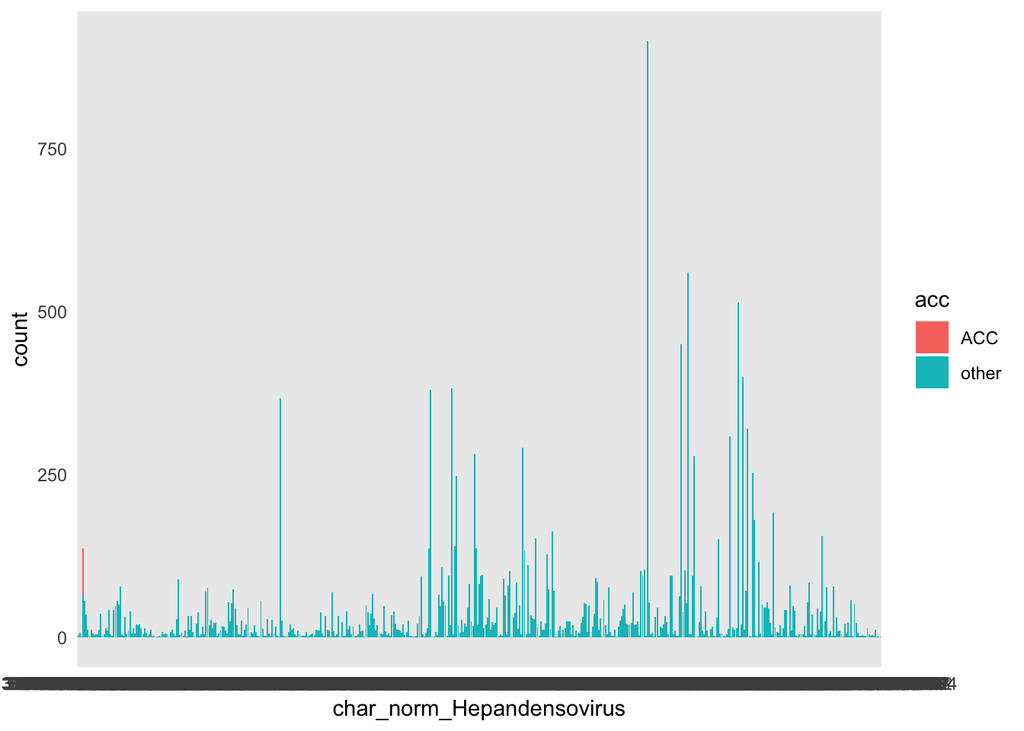

```r
hep_neg$char_norm_Hepandensovirus <- as.character(hep_neg$norm_Hepandensovirus)

hep_neg$investigation <- gsub('TCGA-', '', hep_neg$investigation)

hep_neg <- hep_neg %>% mutate(acc = case_when(
  investigation == 'ACC' ~ 'ACC',
  TRUE ~ 'other'
))

ggplot(hep_neg, aes(x=char_norm_Hepandensovirus, fill=acc)) +
  geom_bar(stat='count') +
  theme_minimal()
```

### How linked is the metadata to cancer type?

Something fishy is going on here. There’s a big batch effect that still seems present. How are these taxa given such specific values?

- Produce a table of the the hospitals where each sample was collected (the variable name is `tissue_source_site_label``)
- Do you notice any hospital names that might be linked with tumour type?

```r
table(metadata$tissue_source_site_label)
```

```
                                                   ABS - IUPUI
                                                           141
                                            ABS - Lahey Clinic
                                                            60
                               ABS - Research Metrics Pakistan
                                                             2
                                                     ABS IUPUI
                                                            22
                                Albert Einstein Medical Center
                                                            15
                                       Alberta Health Services
                                                            91
                          Asbestos Diseases Research Institute
                                                             5
                                                      Asterand
                                                           875
                                      Barretos Cancer Hospital
                                                           185
                                    Baylor College of Medicine
                                                             2
                                              BC Cancer Agency
                                                            28
                                                  BLN - Baylor
                                                            76
                                        BLN - Cleveland Clinic
                                                            26
                                   BLN - University Of Chicago
                                                            90
                                     BLN - University of Miami
                                                             6
                BLN - UT Southwestern Medical Center at Dallas
                                                            11
                                                    BLN Baylor
                                                             1
                  BLN UT Southwestern Medical Center at Dallas
                                                             1
                                         Boston Medical Center
                                                             1
                                  Brigham and Women's Hospital
                                                             8
```

[output cut: 333 more lines]

```
                                                            18
                                   Washington University - NYU
                                                            47
                       Washington University - Rush University
                                                            14
                             Washington University - St. Louis
                                                            15
                               Washington University St. Louis
                                                             6
                                           Wills Eye Institute
                                                             3
                                                          Yale
                                                            57
                                               Yale University
                                                             8
```

Looking at the values we see hospitals like:

- NCI Urologic Oncology Branch
- Gynecologic Oncology Group
- Dept of Neurosurgery at University of Heidelberg

We can see how some hospitals are clearly linked with tumour type. And with a huge batch effect in the data it is likely that this could explain it.